# Explaining Predictions with Shapley Values in R

```r
(params <- ngb$pred_dist(X.val[1, ])$params)
```

```
$loc
[1] -0.4630591

$scale
[1] 0.4360992
```

The code chunk below generates a plot of the estimated cumulative probability density function (i.e., $Pr\left(\texttt{dFRS} <= t\right)$) for the first observation in the validation set; see Figure 1.

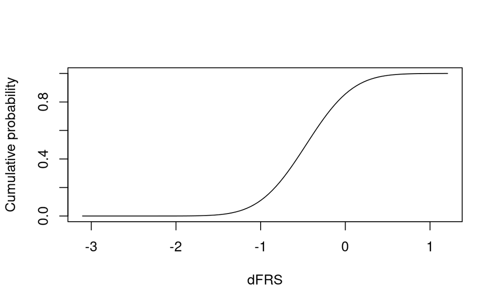

```r
plot(function(x) pnorm(x, mean = params$loc, sd = params$scale),
     from = min(als$dFRS), to = max(als$dFRS),
     xlab = "dFRS", ylab = "Cumulative probability")
```

Since `ngboost` is built on top of `sklearn` (Pedregosa et al. 2011), we can actually use the Python `shap` package (Lundberg and Lee 2017b) to create efficient explanations for the model. Below, we call the `TreeExplainer()` method on the training set and generate global some global interpretations: a variable importance plot, and a *SHAP dependence plot*:

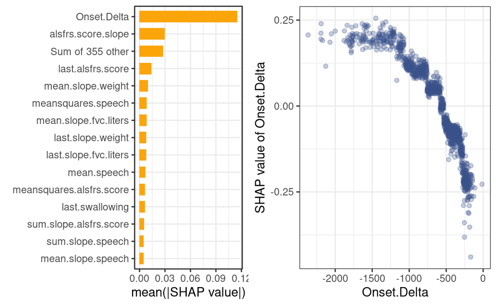

```r
library(ggplot2)
library(shapviz)

# Use 'shap' package to compute SHAP values for entire training set
shap <- import("shap")
explainer <- shap$TreeExplainer(ngb, model_output = 0L)
ex.trn <- explainer$shap_values(X.trn)  # training explanations
colnames(ex.trn) <- colnames(X.trn)

# Construct variable importance and SHAP dependence plots
viz <- shapviz(ex.trn, X = X.trn)
p1 <- sv_importance(viz) + theme_bw()
p2 <- sv_dependence(viz, v = "Onset.Delta", alpha = 0.3) + theme_bw()
gridExtra::grid.arrange(p1, p2, nrow = 1)
```

A `dFRS` of less than -1.1 is considered to be fast progression (Küffner et al. 2015). Hence, it could be useful to estimate the probability of `dFRS < -1.1` and provide an explanation for any individual who’s corresponding probability is considered high. The prediction wrapper (`pfun()`) defined below computes the cumulative probability $Pr\left(\texttt{dFRS} < -1.1 | \boldsymbol{x}\right)$. We use it to determine the observation in the validation set with the highest cumulative probability:

```r
pfun <- function(object, newdata) {
  dist <- object$pred_dist(newdata)
  pnorm(-1.1, mean = dist$params$loc, sd = dist$params$scale)
}

max(prob.val <- pfun(ngb, newdata = X.val))
```

```
[1] 0.7568705
```

```r
xval.max <- X.val[which.max(prob.val), ]  # obs with highest predicted prob
```

```r
library(fastshap)

system.time({
  set.seed(1110)
  ex <- explain(ngb, X = X.trn, nsim = 100, pred_wrapper = pfun,
                newdata = xval.max, adjust = TRUE)
})
```

```
   user  system elapsed
110.365   0.017 110.337
```

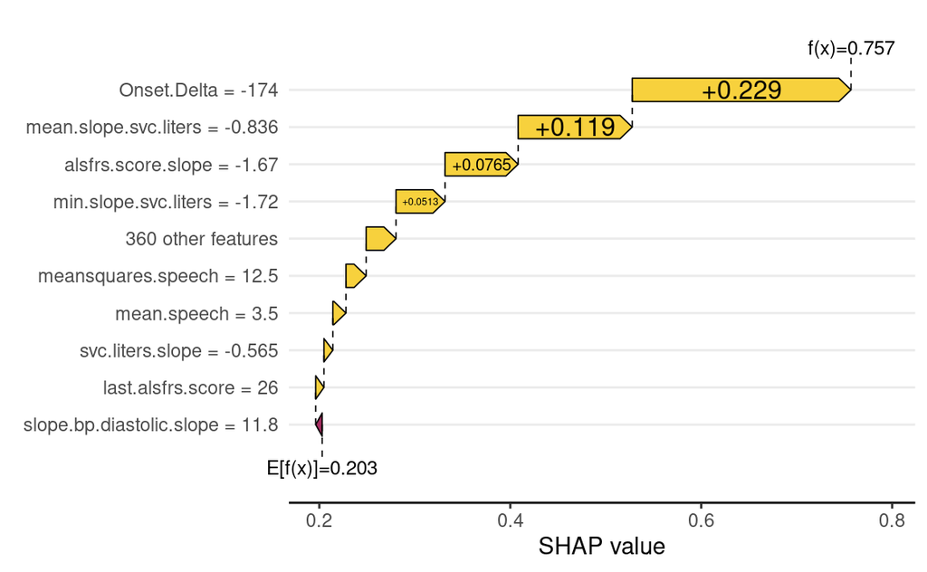

```r
# Visualize with a force plot
viz <- shapviz(ex, X = xval.max, baseline = attr(ex, which = "baseline"))
sv_waterfall(viz, max_display = 10)
```

## CRAN packages used

shapr, shapper, reticulate, pkgsearch, xgboost, fastshap, SHAPforxgboost, iml, iBreakDown, lightgbm, R6, shapviz

## CRAN Task Views implied by cited packages

Databases, HighPerformanceComputing, MachineLearning, ModelDeployment, NumericalMathematics, Survival

K. Aas, M. Jullum and A. Løland. Explaining individual predictions when features are dependent: More accurate approximations to shapley values. 2020. URL https://arxiv.org/abs/1903.10464.

C. H. Achen. *Interpreting and using regression.* Sage Publications, 1982.

P. Biecek, A. Gosiewska, H. Baniecki and A. Izdebski. *iBreakDown: Model agnostic instance level variable attributions.* 2020. URL https://CRAN.R-project.org/package=iBreakDown. R package version 1.3.1.

L. Breiman. Random forests. *Machine Learning*, 45(1): 5–32, 2001. URL https://doi.org/10.1023/A:1010933404324.

W. Chang. *R6: Encapsulated classes with reference semantics.* 2021. URL https://CRAN.R-project.org/package=R6. R package version 2.5.1.

A. Charnes, B. Golany, M. Keane and J. Rousseau. Extremal principle solutions of games in characteristic function form: Core, chebychev and shapley value generalizations. In *Econometrics of planning and efficiency*, Eds J. K. Sengupta and G. K. Kadekodi pages. 123–133 1988. Dordrecht: Springer Netherlands. ISBN 978-94-009-3677-5. URL https://doi.org/10.1007/978-94-009-3677-5_7.

H. Chen, J. D. Janizek, S. Lundberg and S.-I. Lee. True to the model or true to the data? 2020a. URL https://arxiv.org/abs/2006.16234.

T. Chen, T. He, M. Benesty, V. Khotilovich, Y. Tang, H. Cho, K. Chen, R. Mitchell, I. Cano, T. Zhou, et al. *Xgboost: Extreme gradient boosting.* 2020b. URL https://github.com/dmlc/xgboost. R package version 1.2.0.1.

H. A. Chipman, E. I. George and R. E. McCulloch. BART: Bayesian additive regression trees. *The Annals of Applied Statistics*, 4(1): 266–298, 2010. URL https://doi.org/10.1214/09-AOAS285.

I. Covert and S.-I. Lee. Improving KernelSHAP: Practical shapley value estimation via linear regression. 2021. URL https://arxiv.org/abs/2012.01536.

G. Csárdi and M. Salmon. *Pkgsearch: Search and query CRAN r packages.* 2020. URL https://CRAN.R-project.org/package=pkgsearch. R package version 3.0.3.

T. Duan, A. Avati, D. Y. Ding, K. K. Thai, S. Basu, A. Y. Ng and A. Schuler. NGBoost: Natural gradient boosting for probabilistic prediction. 2020. URL https://arxiv.org/abs/1910.03225.

B. Efron and T. Hastie. *Computer age statistical inference: Algorithms, evidence, and data science.* Cambridge University Press, 2016. DOI 10.1017/CBO9781316576533.

J. H. Friedman. Greedy function approximation: A gradient boosting machine. *The Annals of Statistics*, 29(5): 1189–1232, 2001. URL https://doi.org/10.1214/aos/1013203451.

J. H. Friedman. Stochastic gradient boosting. *Computational Statistics & Data Analysis*, 38(4): 367–378, 2002. URL https://doi.org/10.1016/S0167-9473(01)00065-2.

A. Gosiewska and P. Biecek. iBreakDown: Uncertainty of model explanations for non-additive predictive models. *CoRR*, abs/1903.11420: 2019. URL http://arxiv.org/abs/1903.11420.

B. Greenwell. *Fastshap: Fast approximate shapley values.* 2020. URL https://github.com/bgreenwell/fastshap. R package version 0.0.5.9000.

R. Küffner, N. Zach, R. Norel, J. Hawe, D. Schoenfeld, L. Wang, G. Li, L. Fang, L. Mackey, O. Hardiman, et al. Crowdsourced analysis of clinical trial data to predict amyotrophic lateral sclerosis progression. *Nature Biotechnology*, 33(1): 51–57, 2015. URL https://doi.org/10.1038/nbt.3051.

S. M. Lundberg, G. Erion, H. Chen, A. DeGrave, J. M. Prutkin, B. Nair, R. Katz, J. Himmelfarb, N. Bansal and S.-I. Lee. From local explanations to global understanding with explainable AI for trees. *Nature Machine Intelligence*, 2(1): 2522–5839, 2020.

S. M. Lundberg and S.-I. Lee. A unified approach to interpreting model predictions. In *Advances in neural information processing systems 30*, Eds I. Guyon, U. V. Luxburg, S. Bengio, H. Wallach, R. Fergus, S. Vishwanathan and R. Garnett pages. 4765–4774 2017b. Curran Associates, Inc. URL http://papers.nips.cc/paper/7062-a-unified-approach-to-interpreting-model-predictions.pdf.

S. M. Lundberg and S.-I. Lee. A unified approach to interpreting model predictions. In *Advances in neural information processing systems 30*, Eds I. Guyon, U. V. Luxburg, S. Bengio, H. Wallach, R. Fergus, S. Vishwanathan and R. Garnett pages. 4765–4774 2017a. Curran Associates, Inc. URL http://papers.nips.cc/paper/7062-a-unified-approach-to-interpreting-model-predictions.pdf.

J. D. Malley, J. Kruppa, A. Dasgupta, K. G. Malley and A. Ziegler. Probability machines: Consistent probability estimation using nonparametric learning machines. *Methods of Information in Medicine*, 51(1): 74–81, 2012. URL https://doi.org/10.3414/ME00-01-0052.

M. Mayer. *Shapviz: SHAP visualizations.* 2022. URL https://CRAN.R-project.org/package=shapviz. R package version 0.2.1.

C. Molnar. *Interpretable machine learning: A guide for making black box models explainable.* 2019. https://christophm.github.io/interpretable-ml-book/.

C. Molnar and P. Schratz. *Iml: Interpretable machine learning.* 2020. URL https://CRAN.R-project.org/package=iml. R package version 0.10.1.

J. Pearl. *Causality: Models, reasoning and inference.* 2nd ed USA: Cambridge University Press, 2009.

F. Pedregosa, G. Varoquaux, A. Gramfort, V. Michel, B. Thirion, O. Grisel, M. Blondel, P. Prettenhofer, R. Weiss, V. Dubourg, et al. Scikit-learn: Machine learning in Python. *Journal of Machine Learning Research*, 12: 2825–2830, 2011.

R. A. Rigby and M. D. Stasinopoulos. Generalized additive models for location, scale and shape. *Journal of the Royal Statistical Society: Series C (Applied Statistics)*, 54(3): 507–554, 2005. URL https://rss.onlinelibrary.wiley.com/doi/abs/10.1111/j.1467-9876.2005.00510.x.

L. S. Shapley. 17. A value for n-person games. In *Contributions to the theory of games (AM-28), volume II*, Eds H. W. Kuhn and A. W. Tucker pages. 307–318 2016. Princeton University Press. URL https://doi.org/10.1515/9781400881970-018.

Y. Shi, G. Ke, D. Soukhavong, J. Lamb, Q. Meng, T. Finley, T. Wang, W. Chen, W. Ma, Q. Ye, et al. *Lightgbm: Light gradient boosting machine.* 2022. URL https://CRAN.R-project.org/package=lightgbm. R package version 3.3.2.

E. Štrumbelj and I. Kononenko. Explaining prediction models and individual predictions with feature contributions. *Knowledge and Information Systems*, 31(3): 647–665, 2014. URL https://doi.org/10.1007/s10115-013-0679-x.

Q. Zhao and T. Hastie. Causal interpretations of black-box models. *Journal of Business & Economic Statistics*, 39(1): 272–281, 2021. URL https://doi.org/10.1080/07350015.2019.1624293.